# The Birth Data Project

Heyue Cheng

February 21, 2020

The goal of this project is to do data analysis on baby births and populations using R studio to explore the distribution and tendency crossing recent 40 years in the United States by analyzing the relationship among geographical regions, states, races, baby weights, genders, and mother’s age. Data visualization methods such as ggplots and boxplots are used in this project as well to help people draw patterns and make conclusions easily and precisely.

The dataset contains information about births in the United States. The full data set is from the Centers for Disease Control. The data for this project is a “small” sample (chosen at random) of slightly over one million records from the full data set. The data for this project also only contain a subset of the variables in the full data set.

## Setting up

Load `tidyverse`, which includes `dplyr`, `ggplot2`, `tidyr`, and other packages, and the load `knitr`.

```r
library(tidyverse)
library(knitr)
```

Read in the data and convert the data frame to a tibble.

```r
birth_data <- read.csv("BirthData.csv", header = TRUE)
birth_data <- as_tibble(birth_data)
head(birth_data)
```

| year | month | state | is_male | weight_pounds | mother_age | child_race | plurality |
| --- | --- | --- | --- | --- | --- | --- | --- |
| 1969 | 9 | AL | FALSE | 1.624807 | 20 | 2 | NA |
| 1969 | 8 | AZ | TRUE | 7.500126 | 35 | 1 | NA |
| 1969 | 9 | AZ | TRUE | 8.937540 | 17 | 1 | NA |
| 1969 | 2 | CA | TRUE | 6.999677 | 20 | 1 | NA |
| 1969 | 3 | CA | FALSE | 6.876218 | 25 | 2 | NA |
| 1969 | 5 | CA | TRUE | 7.187070 | 30 | 1 | NA |

```r
attach(birth_data)
```

A glimpse of the data:

```r
glimpse(birth_data)
```

```
Rows: 1,103,629
Columns: 8
$ year          <int> 1969, 1969, 1969, 1969, 1969, 1969, 1969, 1969, 1969, 1…
$ month         <int> 9, 8, 9, 2, 3, 5, 5, 5, 6, 8, 8, 11, 11, 11, 1, 12, 3, …
$ state         <fct> AL, AZ, AZ, CA, CA, CA, CA, CA, CA, CA, CA, CA, CA, CA,…
$ is_male       <lgl> FALSE, TRUE, TRUE, TRUE, FALSE, TRUE, FALSE, TRUE, TRUE…
$ weight_pounds <dbl> 1.624807, 7.500126, 8.937540, 6.999677, 6.876218, 7.187…
$ mother_age    <int> 20, 35, 17, 20, 25, 30, 17, 22, 26, 26, 19, 25, 26, 26,…
$ child_race    <int> 2, 1, 1, 1, 2, 1, 1, 4, 2, 1, 1, 1, 2, 1, 1, 1, 1, 1, 1…
$ plurality     <int> NA, NA, NA, NA, NA, NA, NA, NA, NA, NA, NA, NA, NA, NA,…
```

The variables in the data set are:

| Variable | Description |
| --- | --- |
| `year` | the year of the birth |
| `month` | the month of the birth |
| `state` | the state where the birth occurred, including “DC” for Washington D.C. |
| `is_male` | which is `TRUE` if the child is male, `FALSE` otherwise |
| `weight_pounds` | the child’s birth weight in pounds |
| `mother_age` | the age of the mother |
| `child_race` | race of the child. |
| `plurality` | the number of children born as a result of the pregnancy, with 1 representing a single birth, 2 representing twins, etc. |

## Data structure and wrangling

For both of Questions 1 and 2 you should show the R code used and the output of the `str` and `glimpse` functions applied to the data frame. Use of dplyr functions and the pipe operator is highly recommended.

### Question 1

Create a variable called `region` in the data frame `birth_data` which takes the values `Northeast`, `Midwest`, `South`, and `West`.

Here are the states in each region:

##### Northeast Region:

Connecticut, Maine, Massachusetts, New Hampshire, Rhode Island and Vermont, New Jersey, New York, and Pennsylvania

##### Midwest Region:

Illinois, Indiana, Michigan, Ohio and Wisconsin, Iowa, Kansas, Minnesota, Missouri, Nebraska, North Dakota, and South Dakota

##### South Region:

Delaware, District of Columbia, Florida, Georgia, Maryland, North Carolina, South Carolina, Virginia, and West Virginia, Alabama, Kentucky, Mississippi, and Tennessee, Arkansas, Louisiana, Oklahoma, and Texas

##### West Region:

Arizona, Colorado, Idaho, Montana, Nevada, New Mexico, Utah and Wyoming, Alaska, California, Hawaii, Oregon and Washington

```r
# Northeast = c('CT', 'ME', 'MA', 'NH', 'RI', 'VT', 'NJ', 'NY', 'PA' ))

# Midwest = c('IL', 'IN', 'MI', 'OH', 'WI', 'IA', 'KS', 'MN', 'MO', 'NE', 'ND', 'SD'))

# South = c('DE', 'DC', 'FL, KY', 'MS', 'TN', 'AR', 'LA', 'OK', 'TX', 'GA', 'MD', 'NC', 'SC', 'VA', 'WV', 'AL'))

# West = c('AZ', 'CO', 'ID', 'MT', 'NV', 'NM', 'UT', 'WY', 'AK', 'CA', 'HI', 'OR', 'WA'))


birth_data$region[birth_data$state %in% c('CT', 'ME', 'MA', 'NH', 'RI', 'VT', 'NJ', 'PA', 'NY' )] = 'Northeast'

birth_data$region[birth_data$state %in% c('IL', 'IN', 'MI', 'OH', 'WI', 'IA', 'KS', 'MN', 'MO', 'NE', 'ND', 'SD')] = 'Midwest'

birth_data$region[birth_data$state %in% c('DE', 'DC', 'FL', 'KY', 'MS', 'TN', 'AR', 'LA', 'OK', 'TX', 'GA', 'MD', 'NC', 'SC', 'VA', 'WV', 'AL')] = 'South'

birth_data$region[birth_data$state %in% c('AZ', 'CO', 'ID', 'MT', 'NV', 'NM', 'UT', 'WY', 'AK', 'CA', 'HI', 'OR', 'WA')] = 'West'

head(birth_data)
```

| year | month | state | is_male | weight_pounds | mother_age | child_race | plurality | region |
| --- | --- | --- | --- | --- | --- | --- | --- | --- |
| 1969 | 9 | AL | FALSE | 1.624807 | 20 | 2 | NA | South |
| 1969 | 8 | AZ | TRUE | 7.500126 | 35 | 1 | NA | West |
| 1969 | 9 | AZ | TRUE | 8.937540 | 17 | 1 | NA | West |
| 1969 | 2 | CA | TRUE | 6.999677 | 20 | 1 | NA | West |
| 1969 | 3 | CA | FALSE | 6.876218 | 25 | 2 | NA | West |
| 1969 | 5 | CA | TRUE | 7.187070 | 30 | 1 | NA | West |

```r
glimpse(birth_data)
```

```
Rows: 1,103,629
Columns: 9
$ year          <int> 1969, 1969, 1969, 1969, 1969, 1969, 1969, 1969, 1969, 1…
$ month         <int> 9, 8, 9, 2, 3, 5, 5, 5, 6, 8, 8, 11, 11, 11, 1, 12, 3, …
$ state         <fct> AL, AZ, AZ, CA, CA, CA, CA, CA, CA, CA, CA, CA, CA, CA,…
$ is_male       <lgl> FALSE, TRUE, TRUE, TRUE, FALSE, TRUE, FALSE, TRUE, TRUE…
$ weight_pounds <dbl> 1.624807, 7.500126, 8.937540, 6.999677, 6.876218, 7.187…
$ mother_age    <int> 20, 35, 17, 20, 25, 30, 17, 22, 26, 26, 19, 25, 26, 26,…
$ child_race    <int> 2, 1, 1, 1, 2, 1, 1, 4, 2, 1, 1, 1, 2, 1, 1, 1, 1, 1, 1…
$ plurality     <int> NA, NA, NA, NA, NA, NA, NA, NA, NA, NA, NA, NA, NA, NA,…
$ region        <chr> "South", "West", "West", "West", "West", "West", "West"…
```

### Question 2

Create a variable in `birth_data` called `state_color` which takes the values `red`, `blue`, and `purple`, using the following divisions.

##### Red:

Alaska, Idaho, Kansas, Nebraska, North Dakota, Oklahoma, South Dakota, Utah, Wyoming, Texas, Alabama, Mississippi, South Carolina, Montana, Georgia, Missouri, Louisiana, Tennessee, Arkansas, Kentucky, Arizona, West Virginia.

##### Purple:

North Carolina, Virginia, Florida, Ohio, Colorado, Nevada, Indiana, Iowa, New Mexico.

##### Blue:

New Hampshire, Pennsylvania, California, Michigan, Illinois, Maryland, Delaware, New Jersey, Connecticut, Vermont, Maine, Washington, Oregon, Wisconsin, New York, Massachusetts, Rhode Island, Hawaii, Minnesota, District of Columbia.

```r
# Red = 'AK', 'ID', 'KS', 'NE', 'ND', 'OK', 'SD', 'UT', 'WY', 'TX', 'AL', 'MS', 'SC', 'MT', 'GA', 'MO', 'LA', 'TN', 'AR', 'KY', 'AZ', 'WV'

# Purple = 'NC', 'VA', 'FL', 'OH', 'CO', 'NV', 'IN', 'IA', 'NM'

# Blue = 'NH', 'PA', 'CA', 'MI', 'IL', 'MD', 'DE', 'NJ', 'CT', 'VT', 'ME', 'WA', 'OR', 'WI', 'NY', 'MA', 'RI', 'HI', 'MN', 'DC'

birth_data$state_color[birth_data$state %in% c('AK', 'ID', 'KS', 'NE', 'ND', 'OK', 'SD', 'UT', 'WY', 'TX', 'AL', 'MS', 'SC', 'MT', 'GA', 'MO', 'LA', 'TN', 'AR', 'KY', 'AZ', 'WV')] = 'Red'

birth_data$state_color[birth_data$state %in% c('NC', 'VA', 'FL', 'OH', 'CO', 'NV', 'IN', 'IA', 'NM')] = 'Purple'

birth_data$state_color[birth_data$state %in% c('NH', 'PA', 'CA', 'MI', 'IL', 'MD', 'DE', 'NJ', 'CT', 'VT', 'ME', 'WA', 'OR', 'WI', 'NY', 'MA', 'RI', 'HI', 'MN', 'DC')] = 'Blue'

head(birth_data)
```

| year | month | state | is_male | weight_pounds | mother_age | child_race | plurality | region | state_color |
| --- | --- | --- | --- | --- | --- | --- | --- | --- | --- |
| 1969 | 9 | AL | FALSE | 1.624807 | 20 | 2 | NA | South | Red |
| 1969 | 8 | AZ | TRUE | 7.500126 | 35 | 1 | NA | West | Red |
| 1969 | 9 | AZ | TRUE | 8.937540 | 17 | 1 | NA | West | Red |
| 1969 | 2 | CA | TRUE | 6.999677 | 20 | 1 | NA | West | Blue |
| 1969 | 3 | CA | FALSE | 6.876218 | 25 | 2 | NA | West | Blue |
| 1969 | 5 | CA | TRUE | 7.187070 | 30 | 1 | NA | West | Blue |

```r
glimpse(birth_data)
```

```
Rows: 1,103,629
Columns: 10
$ year          <int> 1969, 1969, 1969, 1969, 1969, 1969, 1969, 1969, 1969, 1…
$ month         <int> 9, 8, 9, 2, 3, 5, 5, 5, 6, 8, 8, 11, 11, 11, 1, 12, 3, …
$ state         <fct> AL, AZ, AZ, CA, CA, CA, CA, CA, CA, CA, CA, CA, CA, CA,…
$ is_male       <lgl> FALSE, TRUE, TRUE, TRUE, FALSE, TRUE, FALSE, TRUE, TRUE…
$ weight_pounds <dbl> 1.624807, 7.500126, 8.937540, 6.999677, 6.876218, 7.187…
$ mother_age    <int> 20, 35, 17, 20, 25, 30, 17, 22, 26, 26, 19, 25, 26, 26,…
$ child_race    <int> 2, 1, 1, 1, 2, 1, 1, 4, 2, 1, 1, 1, 2, 1, 1, 1, 1, 1, 1…
$ plurality     <int> NA, NA, NA, NA, NA, NA, NA, NA, NA, NA, NA, NA, NA, NA,…
$ region        <chr> "South", "West", "West", "West", "West", "West", "West"…
$ state_color   <chr> "Red", "Red", "Red", "Blue", "Blue", "Blue", "Blue", "B…
```

Some of the variables have missing values, and these may be related to different data collection choices during different years. For example, possibly plurality wasn’t recorded during some years, or state of birth wasn’t recorded during some years. In this part we investigate using some `dplyr` functions.

### Question 3

Count the number of missing values in each variable in the data frame.

```r
# 1 is row, 2 is column
apply(birth_data, 2, function(x)sum(is.na(x)))
```

```
         year         month         state       is_male weight_pounds
            0             0        135937             0          1660
   mother_age    child_race     plurality        region   state_color
            0        201636         29088        135937        135937
```

### Question 4

Use `group_by` and `summarize` to count the number of missing values of the two variables, `state` and `child_race`, for each year, and to also count the total number of observations per year.

Are there particular years when these two variables are either not available, or of limited availability?

```r
# NA count for 'state'

# functions after 'groupby', don't add "dataset name$", if you do so, it will ignore your groupby function and make you fail in groupby.
birth_data %>%
group_by(year) %>%
summarise(state = sum(is.na(state)),
          race = sum(is.na(child_race)),
          num_obs = length(year)) # count for total numbers of observations
```

| year | state | race | num_obs |
| --- | --- | --- | --- |
| 1969 | 0 | 0 | 14280 |
| 1970 | 0 | 0 | 14808 |
| 1971 | 0 | 0 | 14209 |
| 1972 | 0 | 0 | 14106 |
| 1973 | 0 | 0 | 14840 |
| 1974 | 0 | 0 | 16432 |
| 1975 | 0 | 0 | 18194 |
| 1976 | 0 | 0 | 19537 |
| 1977 | 0 | 0 | 22036 |
| 1978 | 0 | 0 | 23064 |

[output cut: 30 more lines]

### Question 5

Create the following data frame which gives the counts, the mean weight of babies and the mean age of mothers for the six levels of `plurality`. Comment on what you notice about the relationship of plurality and birth weight, and the relationship of plurality and age of the mother.

```r
birth_data %>%
group_by(plurality) %>%
# 'data.frame' is not the only way to create a dataframe. "summarise()" also works
summarise(count = n(), mean.weight = mean(weight_pounds, na.rm = TRUE), mean.age = mean(mother_age, na.rm = TRUE))
```

| plurality | count | mean.weight | mean.age |
| --- | --- | --- | --- |
| 1 | 1046856 | 7.371646 | 26.26753 |
| 2 | 26582 | 5.219283 | 28.09232 |
| 3 | 1018 | 3.740291 | 30.74361 |
| 4 | 75 | 2.814499 | 31.28000 |
| 5 | 10 | 2.052945 | 30.90000 |
| NA | 29088 | 7.207210 | 24.60719 |

### Question 6

Create a data frame which gives the counts, the mean weight of babies and the mean age of mothers for each combination of the three levels of `state_color` and the two levels of `is_male`.

```r
birth_data %>%
# group by multiply variables
group_by(state_color, is_male,) %>%
summarise(count = n(), mean.weight = mean(weight_pounds, na.rm = TRUE), mean.age = mean(mother_age, na.rm = TRUE))
```

| state_color | is_male | count | mean.weight | mean.age |
| --- | --- | --- | --- | --- |
| Blue | FALSE | 227900 | 7.235693 | 26.76948 |
| Blue | TRUE | 241398 | 7.500449 | 26.73520 |
| Purple | FALSE | 94073 | 7.161892 | 25.87084 |
| Purple | TRUE | 99079 | 7.426253 | 25.85514 |
| Red | FALSE | 148892 | 7.145277 | 25.27160 |
| Red | TRUE | 156350 | 7.411161 | 25.29594 |
| NA | FALSE | 66384 | 7.080728 | 27.39311 |
| NA | TRUE | 69553 | 7.303129 | 27.44004 |

## Data Visualisation:

Combine `dplyr`with `ggplot2` to create graphical displays of the data. Use `filter`, `group_by`, and `summarize` build the required data frame.

### Question 1

Create a plot of mean age of mother versus year, which includes separate lines for each of the four regions of the country. (Don’t include data for which the region is missing.)

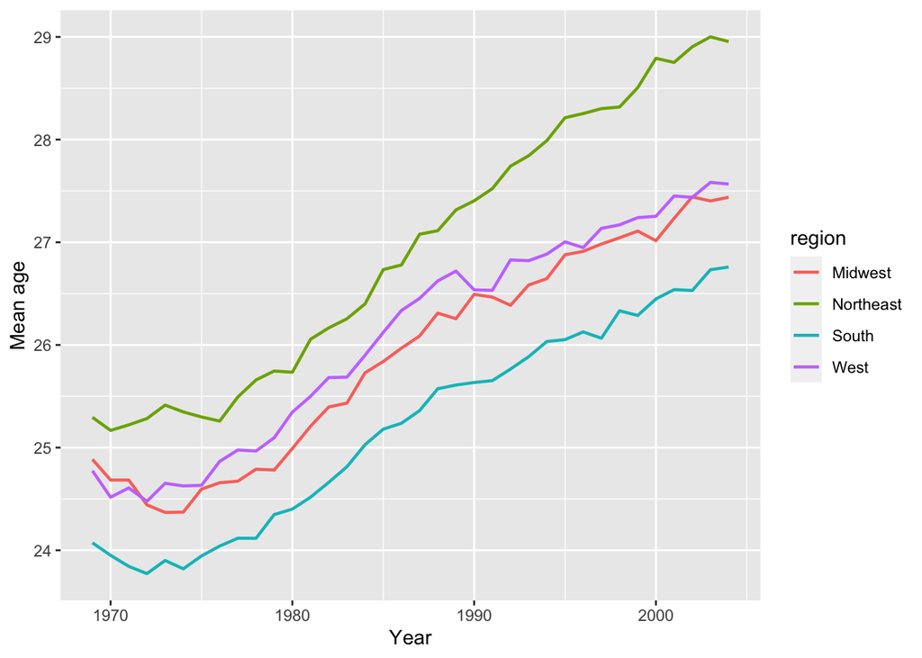

```r
birth_data %>%
filter(!is.na(region)) %>% # another way to exclude NA

group_by(year, region) %>%
summarise(mean.age = mean(mother_age, na.rm = TRUE)) %>%

ggplot(aes(x=as.numeric(year), y=mean.age, color=region)) + # different colors based on regions
geom_line(size = 0.8) + # traces
labs(x='Year', y='Mean age')
```

### Question 2

Create a graphic of mean age of mother versus year, which includes separate lines for each of the three values of `state_color`. (Don’t include data for which `state_color` is missing.)

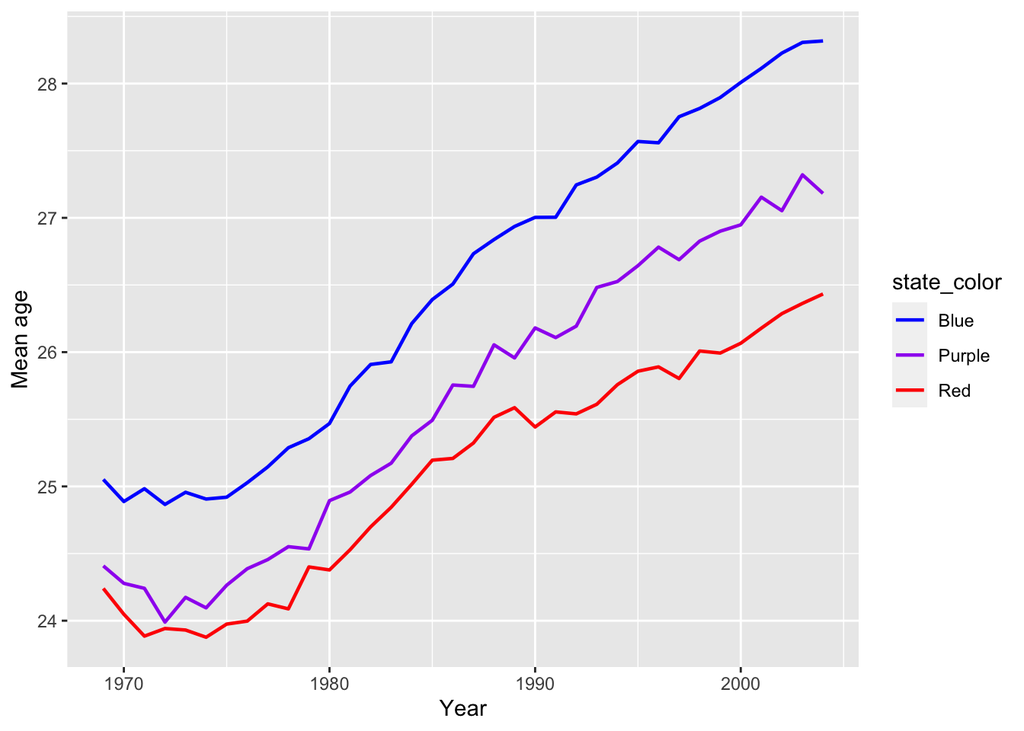

```r
birth_data %>%
filter(!is.na(state_color)) %>%

group_by(year, state_color) %>%
summarise(mean.age = mean(mother_age, na.rm = TRUE)) %>%

ggplot(aes(x=as.numeric(year), y=mean.age, color=state_color)) +
geom_line(size = 0.8) +
labs(x='Year', y='Mean age') +

# change the default color
scale_color_manual(values = c('blue', 'purple', 'red'))
```

### Question 3

Create a graphic of mean weight of the child versus year, which includes separate lines for the two top race categories, white and black. You’ll want to investigate `scale_color_discrete` to change the legend.

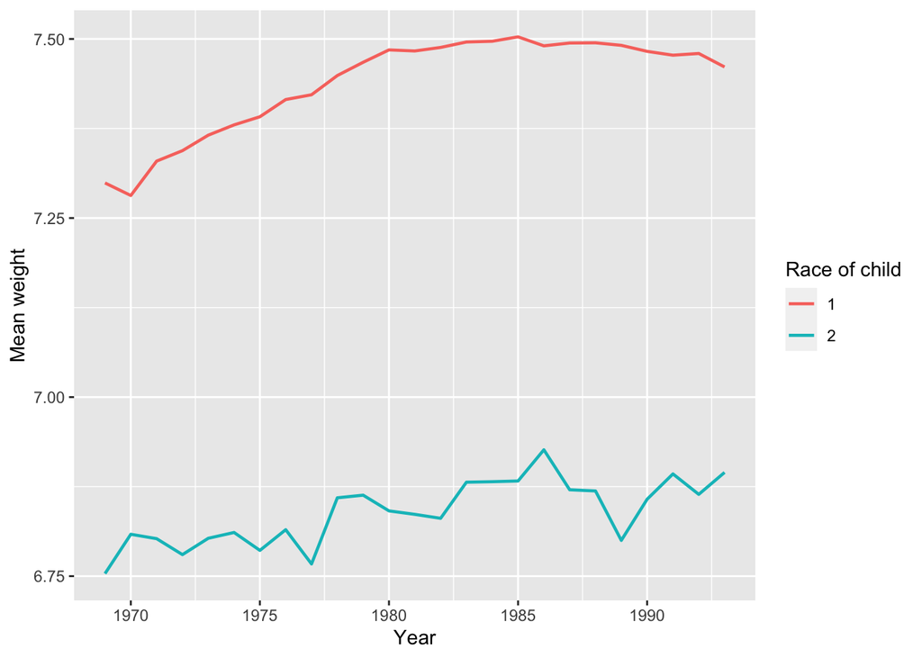

```r
birth_data %>%
# Pick only the 2 top races. The relation is 'union' here, so we should use 'OR'
filter(child_race == 1 | child_race == 2) %>%

group_by(year, child_race) %>%
summarise(mean.weight = mean(weight_pounds, na.rm = TRUE)) %>%

ggplot(aes(x=as.numeric(year), y=mean.weight, color=as.character(child_race))) + # change numeric variables to character
geom_line(size = 0.8) +
# put 'color' function into labs to change the name of legend
labs(x='Year', y='Mean weight', color = 'Race of child')
```

### Question 4

Create a graphic showing side-by-side boxplots of the age of the mother for the four regions.

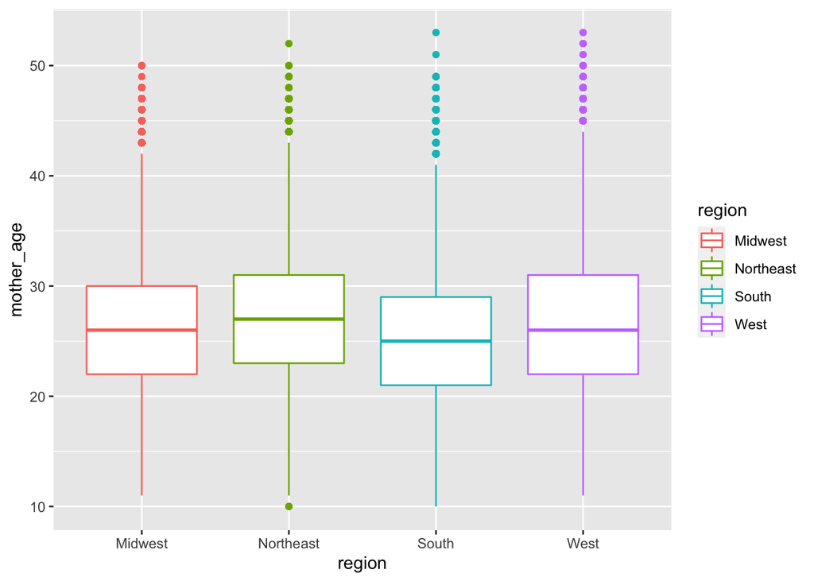

```r
birth_data %>%
# summarise(mean.age = mean(mother_age, na.rm = TRUE)) %>%
filter(!is.na(region)) %>%

ggplot(aes(x=region, y=mother_age, color = region)) +
geom_boxplot() + # boxplot
labs(x='region', y='mother_age')
```

## Reference

1. http://www.cdc.gov/nchs/data_access/Vitalstatsonline.htm